# Лабораторная работа №13

Средства, применяемые при разработке программного обеспечения в ОС типа UNIX/Linux

Рогожина Н.А.

Российский университет дружбы народов, Москва, Россия

14 апреля 2023

# Информация

## Докладчик

- Рогожина Надежда Александровна
- Студентка 1го курса, НКАбд-02-22
- Компьютерные и информационные науки
- Российский университет дружбы народов
- [Github](https://github.com/MikoGreen/study_2022-2023_os-intro)

# Вводная часть

## Цели и задачи

- Приобрести простейшие навыки разработки, анализа, тестирования и отладки приложений в ОС типа UNIX/Linux на примере создания на языке программирования С калькулятора с простейшими функциями.

# Содержание лабораторной работы

## Введение

Стандартным средством для компиляции программ в ОС типа UNIX является GCC (GNU Compiler Collection). Это набор компиляторов для разного рода языков программирования (С, C++, Java, Фортран и др.). Работа с GCC производится при помощи одноимённой управляющей программы `gcc`, которая интерпретирует аргументы командной строки, определяет и осуществляет запуск нужного компилятора для входного файла.

# Задание

## Задачи:

1. В домашнем каталоге создайте подкаталог ~/work/os/lab_prog.
2. Создайте в нём файлы: calculate.h, calculate.c, main.c.

Это будет примитивнейший калькулятор, способный складывать, вычитать, умножать и делить, возводить число в степень, брать квадратный корень, вычислять sin, cos, tan. При запуске он будет запрашивать первое число, операцию, второе число. После этого программа выведет результат и остановится.

3. Выполните компиляцию программы посредством gcc:

```
gcc -c -g calculate.c
gcc -c -g main.c
gcc calculate.o main.o -o calcul -lm
```

4. При необходимости исправьте синтаксические ошибки.

## Задачи:

5. Создайте Makefile.
6. С помощью gdb выполните отладку программы calcul (перед использованием gdb исправьте Makefile):
7. С помощью утилиты splint попробуйте проанализировать коды файлов calculate.c и main.c.

# Выполнение

## Подкаталог

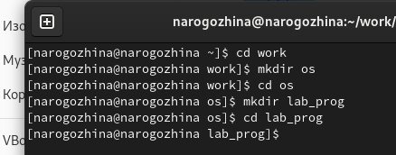

Создание подкаталога

## Файлы

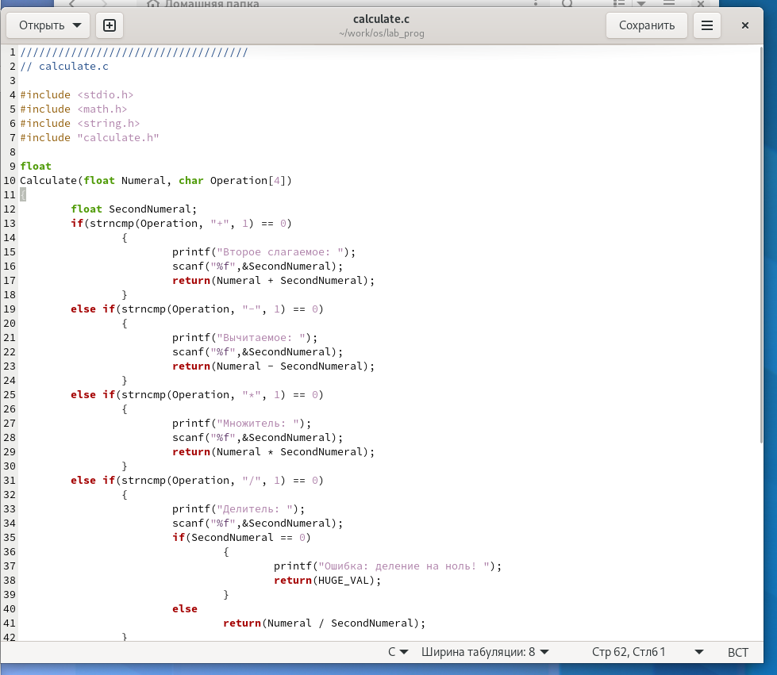

calculate.c

## Файлы

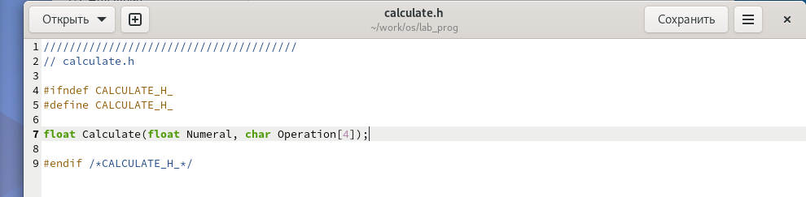

calculate.h

## Файлы

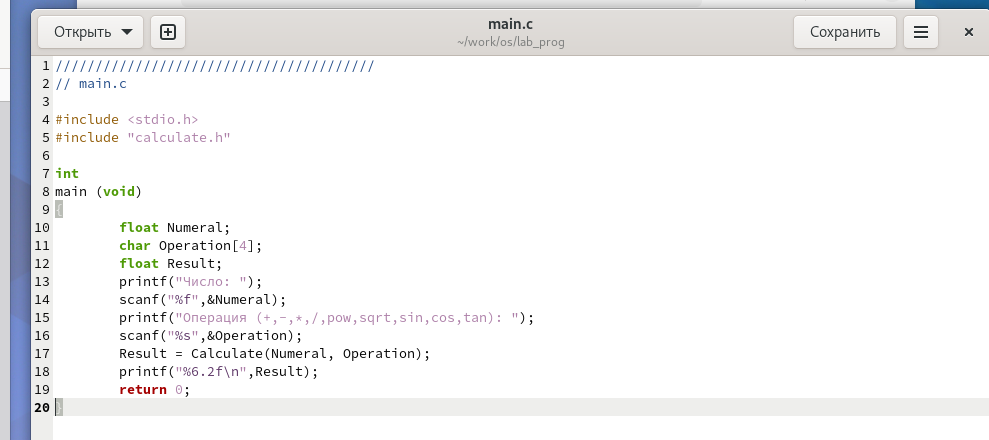

main.c

## Компиляция

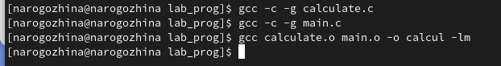

Компиляция программы

## Makefile

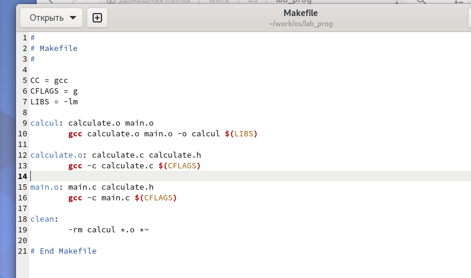

Создание Makefile

## Запуск отладчика и проверка программы

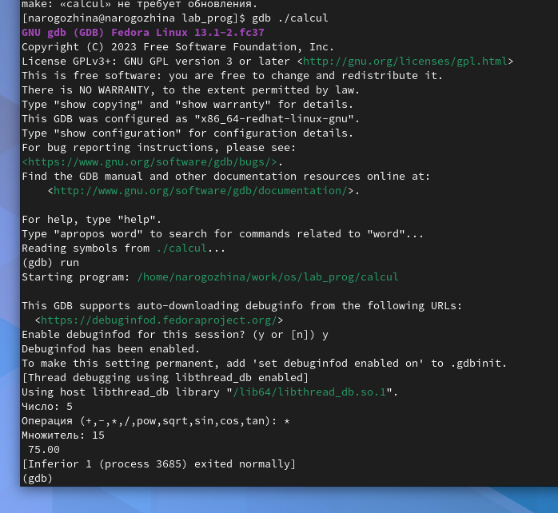

Запуск gdb

## Постраничный просмотр

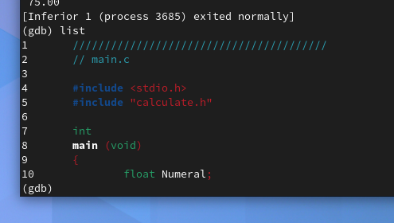

list

## Просмотр определённых строк не основного файла

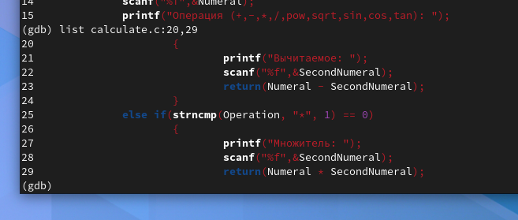

list calculate.c:20,29

## Установка точки остановки в файле calculate.c на строке номер 21

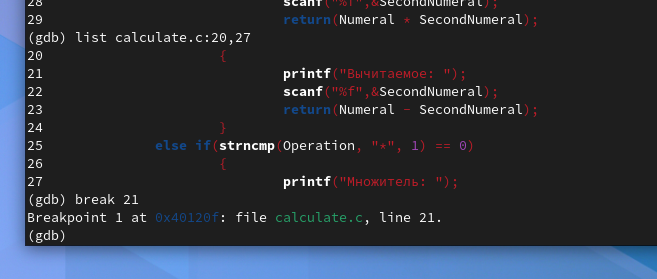

Точка остановки

## Запуск программы

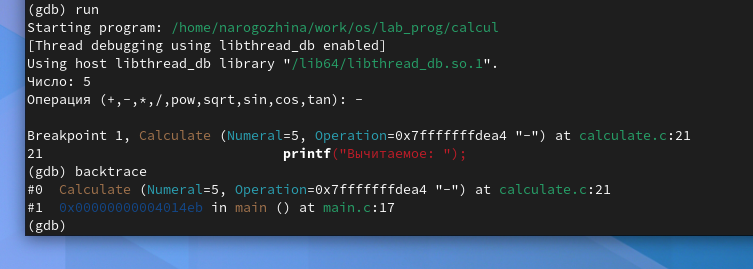

run + backtrace

## Переменная Numeral

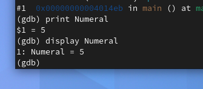

print/display Numeral

## Удаление точек остановки

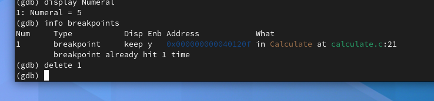

Удаление точек остановки

## Проверка

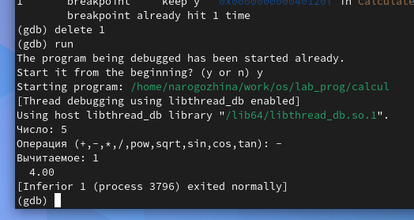

run

## Splint

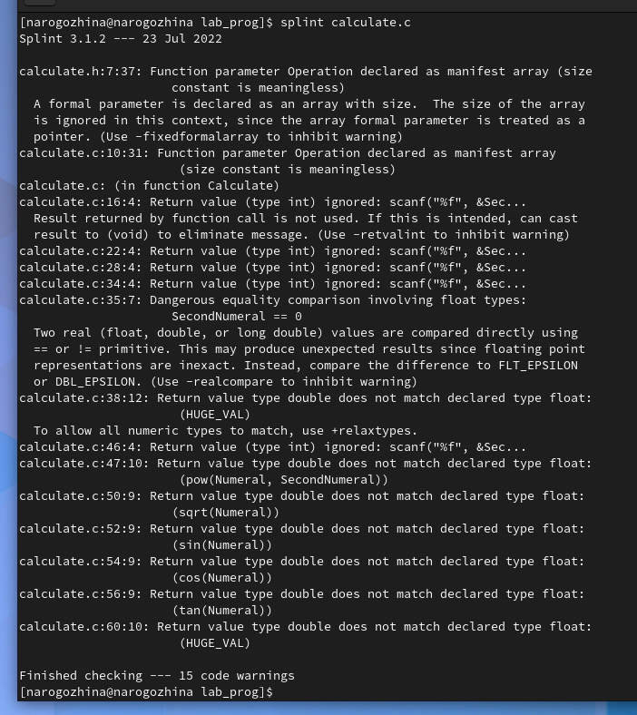

splint calculate.c

## Splint

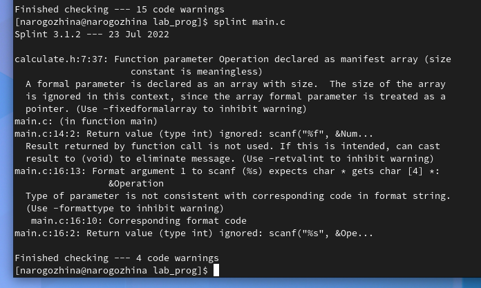

splint main.c

# Выводы

## Выводы

В ходе лабораторной работы мы приобрели простейшие навыки разработки, анализа, тестирования и отладки приложений в ОС типа UNIX/Linux на примере создания на языке программирования С калькулятора с простейшими функциями.